# Titanic Survival Analysis

MD.Mehedi, Tanjena Akter Shefa, Shahriyar Hoque Fihal

2026-09-09

## *Introduction:*

This report explores the survival patterns of passengers on the Titanic to determine whether key demographic and socio-economic factors influenced a person’s likelihood of survival. Specifically, we construct contingency tables, generate bar charts, and perform Chi-square tests of independence to evaluate the impact of passenger sex and ticket class on survival outcomes.

## *SECTION 1: SETUP & DATA PREPARATION*

## *Load the built-in Titanic dataset and convert it to a dataframe*

```r
titanic_df <- as.data.frame(Titanic)
titanic_data <- titanic_df[rep(1:nrow(titanic_df), titanic_df$Freq), -5]
rownames(titanic_data) <- NULL
```

## *Section 2: Survival Analysis by sex*

### *2.1:Contingency Table:*

The contingency table below shows the raw counts of survival broken down by gender.

```r
sex_table <- table(titanic_data$Sex, titanic_data$Survived)
sex_table
```

```
##
##            No  Yes
##   Male   1364  367
##   Female  126  344
```

### *2.2: Visualisation:*

The grouped bar plot below visually highlights the distribution of survivors and non-survivors across both sexes using base R graphics.

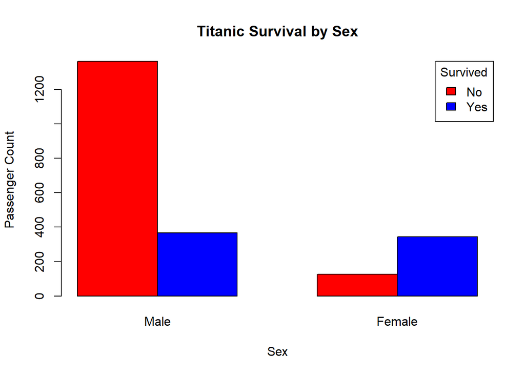

```r
plot_sex_table <- table(titanic_data$Survived, titanic_data$Sex)
barplot(plot_sex_table,
        beside = TRUE,
        col = c("red", 'blue'),
        legend.text = c("No", "Yes"),
        args.legend = list(x = "topright", title = "Survived"),
        main = "Titanic Survival by Sex",
        xlab = "Sex",
        ylab = "Passenger Count")
```

### *2.3: Chi-square Test of independence:*

We test the null hypothesis ( Survival and Sex are completely independent) against the alternative hypothesis (Survival and Sex are dependent).

```r
chisq.test(sex_table)
```

```
##
##  Pearson's Chi-squared test with Yates' continuity correction
##
## data:  sex_table
## X-squared = 454.5, df = 1, p-value < 2.2e-16
```

Because the resulting p-value is extremely small . We reject the null hypothesis. There is strong, statistically significant evidence that survival on the Titanic was dependent on a passenger’s sex.

## *Section 3: Survival Analysis by passenger class:*

### *3.1: Contingency Table:*

The table below displays survival counts across the different ticket classes (1st, 2nd, 3rd, and Crew).

```r
class_table <- table(titanic_data$Class, titanic_data$Survived)
class_table
```

```
##
##         No Yes
##   1st  122 203
##   2nd  167 118
##   3rd  528 178
##   Crew 673 212
```

### *3.2: Visualization:*

The following chart compares the number of survivors and non-survivors across all passenger classes.

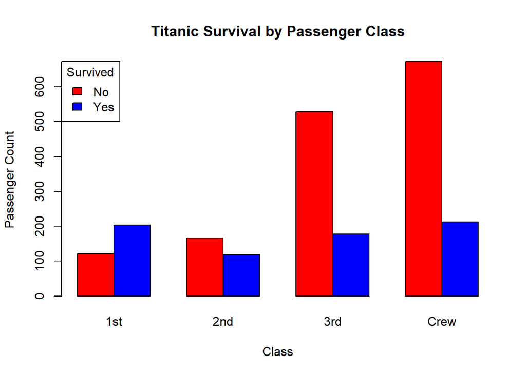

```r
plot_class_table <- table(titanic_data$Survived, titanic_data$Class)

barplot(plot_class_table,
        beside = TRUE,
        col = c("red", "blue"),
        legend.text = c("No", "Yes"),
        args.legend = list(x = "topleft", title = "Survived"),
        main = "Titanic Survival by Passenger Class",
        xlab = "Class",
        ylab = "Passenger Count")
```

### *3.3: Chi-square Test of independence:*

We test the null hypothesis (Survival and Passenger Class are independent) against the alternative hypothesis (Survival and Passenger Class are dependent).

```r
chisq.test(class_table)
```

```
##
##  Pearson's Chi-squared test
##
## data:  class_table
## X-squared = 190.4, df = 3, p-value < 2.2e-16
```

Because the p-value is so small (p < 0.05), the test confirms that survival wasn’t just random. The ticket class heavily influenced the chances of making it off the ship alive.